# Introduction to Bash and R

# Introduction to Bash

(Adapted from LMU’s shell scripting [notebook](https://cs.lmu.edu/~ray/notes/bash/))

**Bash**, the Bourne-Again Shell, refers both to a particular Unix shell program and its associated scripting language. A shell is a command interpreter. Commands can be executable files or built-ins. Commands can be bundled together into a *script* which a shell program executes. How the commands are packaged and wired together, using variables, functions, and control-flow operators makes up the shell’s *scripting language*.

You can think of bash in many ways as a file explorer. Instead of using a mouse to tell the computer where to go and what to do, you relay the instructions to the computer line-by-line with a tool called the **Terminal**.

## Navigation

Bash is our primary tool for interacting with the terminal and importantly allows us to navigate through the computer’s file system.

Let’s see some examples of commands you will find useful throughout the rest of the course.

The command `echo` will simply return any text you give it.

```bash
echo Hello World I am at KAIST
echo We are learning bash!
```

```
Hello World I am at KAIST
We are learning bash!
```

`pwd` displays your current working directory (i.e. the directory that you’re in)

```bash
pwd
```

```
/home/rstudio/work/kaist-rna-bulk-sept2025/src/0_intro_to_R_and_bash
```

`ls` prints the content of a specified directory

```bash
ls .
```

```
0_intro_to_R_and_bash.html
0_intro_to_R_and_bash.qmd
0_intro_to_R_and_bash.rmarkdown
_extensions
MyData.csv
MyData.tsv
report_assets
```

The `.` specifies that we would like to operate on the current directory. Since we are running these from a notebook, the working directory will be the same as that of the notebook (see the output of `pwd` above).

Similarly, typing `..` means you want the shell to look up one directory in the hierarchy. This will be `/home/rstudio/work/kaist-rna-bulk-sept2025/src` in our case.

```bash
ls ..
```

```
0_intro_to_R_and_bash
1_qc
2_mapping
3_quant
4_differential_expression
5_isoform_switch_analysis
```

To change the directory, use the command `cd`

```bash
cd ..  # go up one directory
ls ..  # print the contents of the directory
```

```
data
README.md
src
```

Beware that every *code chunk* (the blocks with the green arrow) is run *in isolation within a separate bash session*. This means that we effectively return to the original directory after execution of the code cell. You can test this by running the cell multiple times in a row. The output remains the same because we return to the original directory each time implicitly.

Running the code in the tab below called “terminal” however *does* keep a memory of everything we have executed because it is running a single, uninterrupted session. In the same way as the code blocks above, if we were to terminate Renku and (and exit the bash session above), the next time we log in, we would automatically be placed into the project directory (by default) and not in the directory we were in before we closed the session.

Let’s move around a bit more.

```bash
cd ../..
ls
```

```
data
README.md
src
```

The `/` character separates directories, so placing it between two `..` means we move up **2** directories instead of one.

Let’s navigate into the `data` directory in the root project directory.

```bash
cd ../../data
ls
```

```
adapter_list.txt
allIllumina-forTrimmomatic-20160202.fa
```

Here, we again move up two directories, then into the data directory. Validate this result by using the file explorer on the right.

## Commands

`cd` and `ls` are commands, and there are many more such commands in bash for performing various tasks. In fact, many more such commands exist and all of the tools in the first few sections of the practicals will have corresponding executions on the command line.

As an example, `realpath` specifies the **absolute path** of a given directory. This is the path relative to the **root** of the file system you are on and they will all start with `/`.

Let’s print the absolute path of the current working directory.

```bash
realpath .
```

```
/home/rstudio/work/kaist-rna-bulk-sept2025/src/0_intro_to_R_and_bash
```

`pwd` already prints the absolute path of the current working directory, so the output of this command will be the same as running the above cell block.

Many tools have special **options** which change the way the tool behaves. These are usually specified in bash using a single `-` or two dashes `--` if you want to use the longform alias.

`ls` has two options which I find very useful.

`-l` prints the output line-by-line and gives you some information about the size of each file and who has access to it.

`-h` prints the `-l` output in a more human readable format (i.e. converting bytes into gigabtyes, megabytes, etc.)

```bash
cd ../../data
ls -lh
```

```
total 8.0K
-rw-r--r-- 1 rstudio rstudio 2.2K Sep 12 15:36 adapter_list.txt
-rw-r--r-- 1 rstudio rstudio 1.6K Sep 12 15:36 allIllumina-forTrimmomatic-20160202.fa
```

## The root directory

Let’s see what’s actually inside the root directory `/`

```bash
ls -lh /
```

```
total 112K
lrwxrwxrwx   1 root root    7 Apr 22  2024 bin -> usr/bin
drwxr-xr-x   2 root root 4.0K Apr 22  2024 boot
drwxr-xr-x   5 root root  360 Sep 12 15:36 dev
-rwxr-xr-x   1 root root 1.9K Feb 25  2025 entrypoint.sh
drwxr-xr-x   1 root root 4.0K Aug 15 15:22 etc
drwxr-xr-x   1 root root 4.0K Aug  6 08:09 home
-rwxr-xr-x   1 root root  389 Oct 20  2020 init
lrwxrwxrwx   1 root root    7 Apr 22  2024 lib -> usr/lib
lrwxrwxrwx   1 root root    9 Apr 22  2024 lib64 -> usr/lib64
drwxr-xr-x   2 root root 4.0K Oct  9  2020 libexec
drwxr-xr-x   2 root root 4.0K Nov 14  2024 lib.usr-is-merged
drwxr-xr-x   2 root root 4.0K May 29 02:14 media
drwxr-xr-x   2 root root 4.0K May 29 02:14 mnt
drwxr-xr-x   1 root root 4.0K Aug  6 08:08 opt
-rwxr-xr-x   1 root root 1.3K Aug  5 16:11 post-init.sh
dr-xr-xr-x 301 root root    0 Sep 12 15:36 proc
drwxr-xr-x   2 root root 4.0K Aug  6 08:08 renku
drwxr-xr-x   1 root root 4.0K Jun 13 10:04 rocker_scripts
drwx------   1 root root 4.0K Jun 13 15:11 root
drwxr-xr-x   1 root root 4.0K Jun 13 15:15 run
lrwxrwxrwx   1 root root    8 Apr 22  2024 sbin -> usr/sbin
drwxr-xr-x   2 root root 4.0K May 29 02:14 srv
dr-xr-xr-x  12 root root    0 Sep 12 15:36 sys
-rwx--x--x   1 root root  24K Dec  7  2021 tini
drwxrwxrwt   1 root root 4.0K Sep 12 15:43 tmp
drwxr-xr-x   1 root root 4.0K May 12  2020 usr
drwxr-xr-x   1 root root 4.0K May 29 02:22 var
```

There are a lot of different files and directories here required for the computer to work. In fact, it contains *all* the programs, data, and settings on your computer (so don’t delete it). You may notice the `/home` directory, which is the directory in which all the course materials are located.

```bash
ls -lh ~/.local/bin
```

```
total 97M
-rwxr-xr-x 1 rstudio rstudio  13M Aug 29 21:34 fastp
lrwxrwxrwx 1 rstudio rstudio   38 Aug 29 21:18 fastqc -> /home/rstudio/.local/bin/FastQC/fastqc
drwxrwxr-x 8 rstudio rstudio 4.0K Mar  1  2023 FastQC
lrwxrwxrwx 1 rstudio rstudio   57 Aug 29 21:34 fastq_screen -> /home/rstudio/.local/bin/FastQ-Screen-0.16.0/fastq_screen
drwxr-xr-x 6 rstudio rstudio 4.0K Sep 20  2024 FastQ-Screen-0.16.0
-rwxr-xr-x 1 rstudio rstudio 8.1M Sep 20  2024 kallisto
-rwxr-xr-x 1 rstudio rstudio 7.0M Aug 29 18:02 samtools
-rwxr-xr-x 1 rstudio rstudio  19M Aug 19 07:35 seqkit
-rwxr-xr-x 1 rstudio rstudio 3.4M Jan 25  2024 STAR
-rwxr-xr-x 1 rstudio rstudio  46M Aug 28 21:38 uv
-rwxr-xr-x 1 rstudio rstudio 361K Aug 28 21:38 uvx
```

## Variables

We often want to save information for later use. Let’s say for example that we want to keep a record of the current working directory, which we will then use later. This is where **variables** come in. Think of them as a bucket into which you can deposit information. We define variables by using the equal sign `=` . In order to *reference a variable*, we use the dollar sign `$` character in front of the variable name.

Let’s say we want to store the text “Hello World” inside a variable x and then print the text. We can also reassign the variable as many times as we want to a different text.

```bash
x="Hello World"
echo $x
echo $x
x="Hello SK"
echo $x
```

```
Hello World
Hello World
Hello SK
```

Bash primarily uses variables to store text output, but other programming languages use variables to store all kinds of information.

## Loops

Often, we would like to perform the same operation on multiple inputs. In the example below, we loop through the some words and print them line-by-line. A **for-loop** can help us with this. The different items are separated by a space. The **body** of a for-loop will be executed for every specified item.

```bash
for TEXT in "abc" "def" "I" "like" "programming"; do
  echo $TEXT
done
```

```
abc
def
I
like
programming
```

The above example is very simple, but for-loops allow us to do many useful things, such as executing the same command for a series of samples to process with a certain tool, for instance. We will see some examples of this in the later notebooks.

## Executing script files

Sometimes, we want to reuse a series of bash command for later use. In this case, we can place the files into a file ending in `.sh` and call `bash` as a command to execute the contents.

First, create a file in the **current directory** containing the following lines and save it as a file called “test.sh”

```bash
echo "Hello World"
cd ..
ls -lh
cd ..
ls -lh
sleep 2
```

```
Hello World
total 24K
drwxr-sr-x 4 rstudio rstudio 4.0K Sep 12 15:43 0_intro_to_R_and_bash
drwxr-sr-x 4 rstudio rstudio 4.0K Sep 12 15:36 1_qc
drwxr-sr-x 5 rstudio rstudio 4.0K Sep 12 15:36 2_mapping
drwxr-sr-x 4 rstudio rstudio 4.0K Sep 12 15:36 3_quant
drwxr-sr-x 4 rstudio rstudio 4.0K Sep 12 15:36 4_differential_expression
drwxr-sr-x 4 rstudio rstudio 4.0K Sep 12 15:36 5_isoform_switch_analysis
total 12K
drwxr-sr-x 2 rstudio rstudio 4.0K Sep 12 15:36 data
-rw-r--r-- 1 rstudio rstudio  450 Sep 12 15:36 README.md
drwxr-sr-x 8 rstudio rstudio 4.0K Sep 12 15:36 src
```

Execute this file by typing the following.

```bash
bash test.sh
```

## Summary

We have just skimmed the surface of what `bash` can do, and you should be able to understand the bash code in the rest of the module a little better now. Still, we encourage you to spend more time getting familiar with bash after this course because it will be instrumental in running not just these analyses, but many other tools and bioinformatic pipelines.

# Introduction to R

R is a powerful, free software environment for statistical computing and graphics. R’s strengths include its vast collection of packages, sophisticated graphing capabilities, and an open-source user community.

- **Free and Open Source**: R is available under the GNU license, granting users essential rights, e.g. to run, study, redistribute, and improve the software.
- **Cross-Platform**: It runs on almost any operating system.
- **Graphics**: R has advanced capabilities for creating high-quality, customizable plots, often considered superior to other statistical packages.

R’s functionality is divided into a base system and thousands of add-on **packages**. These packages are collections of functions, data, and compiled code in a well-defined format.

- **CRAN (The Comprehensive R Archive Network)**: There are around 15,000 packages available on CRAN, developed by users and programmers worldwide.
- **Bioconductor**: This is a separate repository of packages specifically for the analysis and comprehension of high-throughput genomic data.
- **Other Sources**: Many developers also make packages available on personal websites or platforms like GitHub.

## Calculator

R can be used as a simple calculator for arithmetic and other mathematical operations.

```r
# Basic Arithmetic
2 + 2
```

```
[1] 4
```

```r
3 - 5
```

```
[1] -2
```

```r
7 * -3
```

```
[1] -21
```

```r
pi / 3.141592
```

```
[1] 1
```

```r
# Other mathematical functions
2^5
```

```
[1] 32
```

```r
log2(32)
```

```
[1] 5
```

```r
sqrt(2)
```

```
[1] 1.414214
```

## Variables and Assignment

Values can be stored in variables using the assignment operator `<-`. This allows you to save results and use them in later calculations.

```r
# Assign the value 1 to the variable x
x <- 1
x # Auto-printing the content of x
```

```
[1] 1
```

```r
# Assign a character string to a variable
msg <- "hello"
msg
```

```
[1] "hello"
```

```r
# Create a sequence of integers from 1 to 20
x <- 1:20
x
```

```
 [1]  1  2  3  4  5  6  7  8  9 10 11 12 13 14 15 16 17 18 19 20
```

## Workspace and Package Management

Your R session includes a workspace where all created objects are stored. You can manage your working directory and load external functionalities through packages.

```r
# Get the current working directory
getwd()
```

```
[1] "/home/rstudio/work/kaist-rna-bulk-sept2025/src/0_intro_to_R_and_bash"
```

```r
# Set the working directory (replace with your path)
# setwd("/path/to/your/directory")

# List objects in the current workspace
ls()
```

```
[1] "msg" "x"
```

```r
# Remove an object
# rm(x)
```

To use functionality not included in base R, you need to install and load packages.

```r
# Install a package from CRAN (e.g., ISLR)
# The command is run once to download the package.
install.packages("ISLR")
# Install core Bioconductor packages
# if (!requireNamespace("BiocManager", quietly = TRUE))
#     install.packages("BiocManager")
# BiocManager::install()

# Install specific Bioconductor packages
# BiocManager::install(c("GenomicFeatures", "AnnotationDbi"))


# Load a package to use its functions in the current session
library(ISLR)
```

## Getting Help

R has a comprehensive built-in help system.

```r
# Get specific help for a function (exact match)
?mean

# Search for help pages related to a topic (partial match)
??plot
```

## Data Structures in R

R has several fundamental data structures for storing different kinds of data.

A vector is a one-dimensional collection of elements of the same type (numeric, character, logical, etc.). They are most commonly created with the `c()` function.

```r
# Numeric vector
x_numeric <- c(0.5, 0.6)

# Logical vector
x_logical <- c(TRUE, FALSE, T, F)

# Character vector
x_character <- c("a", "b", "c")

# Integer sequence vector
x_integer <- 9:29

# Performing vectorized operations
x <- 1:4
y <- 6:9

x + y  # Element-wise addition
```

```
[1]  7  9 11 13
```

```r
x * y  # Element-wise multiplication
```

```
[1]  6 14 24 36
```

```r
x > 2  # Logical comparison
```

```
[1] FALSE FALSE  TRUE  TRUE
```

### Matrices

A matrix is a two-dimensional vector with **rows** and **columns**. All elements must be of the same type.

```r
# Create a 2x3 matrix filled with NA by default
m <- matrix(nrow = 2, ncol = 3)
m
```

```
     [,1] [,2] [,3]
[1,]   NA   NA   NA
[2,]   NA   NA   NA
```

```r
# Create a matrix from a vector, filling by column
m <- matrix(1:6, nrow = 2, ncol = 3)
m
```

```
     [,1] [,2] [,3]
[1,]    1    3    5
[2,]    2    4    6
```

### Factors

Factors are used to represent categorical data. They are useful because they are self-describing; for example, “Male” and “Female” are more informative than 1 and 2.

```r
# Create a factor
x <- factor(c("yes", "yes", "no", "yes", "no"))
x
```

```
[1] yes yes no  yes no
Levels: no yes
```

```r
# See the frequency of each level
table(x)
```

```
x
 no yes
  2   3
```

```r
# The default level order is alphabetical. We can change it.
x <- factor(c("yes", "yes", "no", "yes", "no"),
            levels = c("yes", "no"))
x
```

```
[1] yes yes no  yes no
Levels: yes no
```

### Data Frames

Data frames are table-like structures used to store tabular data. Unlike matrices, columns in a data frame can be of different data types (e.g., numeric, character, factor).

```r
# Create a data frame
df <- data.frame(
  foo = 1:4,
  bar = c(T, T, F, F)
)
df
```

```
  foo   bar
1   1  TRUE
2   2  TRUE
3   3 FALSE
4   4 FALSE
```

```r
# Get the number of rows and columns
nrow(df)
```

```
[1] 4
```

```r
ncol(df)
```

```
[1] 2
```

## Data Handling

### Subsetting

You can extract specific parts of R objects using subsetting operators.

- `[`: Extracts elements and always returns an object of the same class as the original. Can select multiple elements.
- `[[`: Extracts a single element from a list or data frame.
- `$`: Extracts elements from a data frame by name.

```r
# --- Subsetting a Vector ---
x <- c("a", "b", "c", "c", "d", "a")
x[1]        # First element
```

```
[1] "a"
```

```r
x[1:4]      # First four elements
```

```
[1] "a" "b" "c" "c"
```

```r
x[x > "a"]  # Logical subsetting
```

```
[1] "b" "c" "c" "d"
```

```r
# --- Subsetting a Data Frame ---
df <- data.frame(
  number = 1:4,
  logic = c(T, T, F, F)
)

# Using $
df$number
```

```
[1] 1 2 3 4
```

```r
# Using [[
df[[1]]
```

```
[1] 1 2 3 4
```

```r
# Using [ rows, columns ]
df[1, ]      # First row, all columns
```

```
  number logic
1      1  TRUE
```

```r
df[, 2]      # All rows, second column
```

```
[1]  TRUE  TRUE FALSE FALSE
```

```r
df[c(1, 3), 2] # First and third rows of the second column
```

```
[1]  TRUE FALSE
```

### Handling Missing Values (NA)

Missing values are represented by `NA`. They can be identified and removed to perform calculations.

```r
x <- c(1, 2, NA, 4, NA, 5)

# Create a logical vector indicating which values are NA
is_na <- is.na(x)
is_na
```

```
[1] FALSE FALSE  TRUE FALSE  TRUE FALSE
```

```r
# Select only the non-NA values
x[!is_na]
```

```
[1] 1 2 4 5
```

```r
# For multiple objects, use complete.cases to find rows with no NAs
y <- c("a", "b", NA, "d", NA, "f")
good_cases <- complete.cases(x, y)
good_cases
```

```
[1]  TRUE  TRUE FALSE  TRUE FALSE  TRUE
```

```r
# Subset both vectors based on complete cases
x[good_cases]
```

```
[1] 1 2 4 5
```

```r
y[good_cases]
```

```
[1] "a" "b" "d" "f"
```

### Reading and Writing Data

You can easily import data from and export data to external files.

```r
# Create a sample data frame to write to a file
my_data <- data.frame(
  Company = c("CompanyA", "CompanyB", "CompanyC", "CompanyD"),
  Aircrafts = c(161, 52, 280, 432),
  Accidents = c(3, 8, 2, 10)
)

# Write to a tab-separated file (.xls or .tsv)
write.table(my_data,
            file = "MyData.tsv",
            sep = "\t",
            row.names = FALSE,
            quote = FALSE)

# Write to a comma-separated file (.csv)
write.table(my_data,
            file = "MyData.csv",
            sep = ",",
            row.names = FALSE,
            quote = FALSE)

# Read from a tab-separated file
data_from_file <- read.delim("MyData.tsv", header = TRUE)
str(data_from_file) # Check the structure of the imported data
```

```
'data.frame':   4 obs. of  3 variables:
 $ Company  : chr  "CompanyA" "CompanyB" "CompanyC" "CompanyD"
 $ Aircrafts: int  161 52 280 432
 $ Accidents: int  3 8 2 10
```

### Data Visualization

R’s base graphics system provides a flexible way to create a wide variety of plots.

### Scatter and Line Plots

The `plot()` function is a generic function for creating plots. The `type` argument controls the style (points, lines, both).

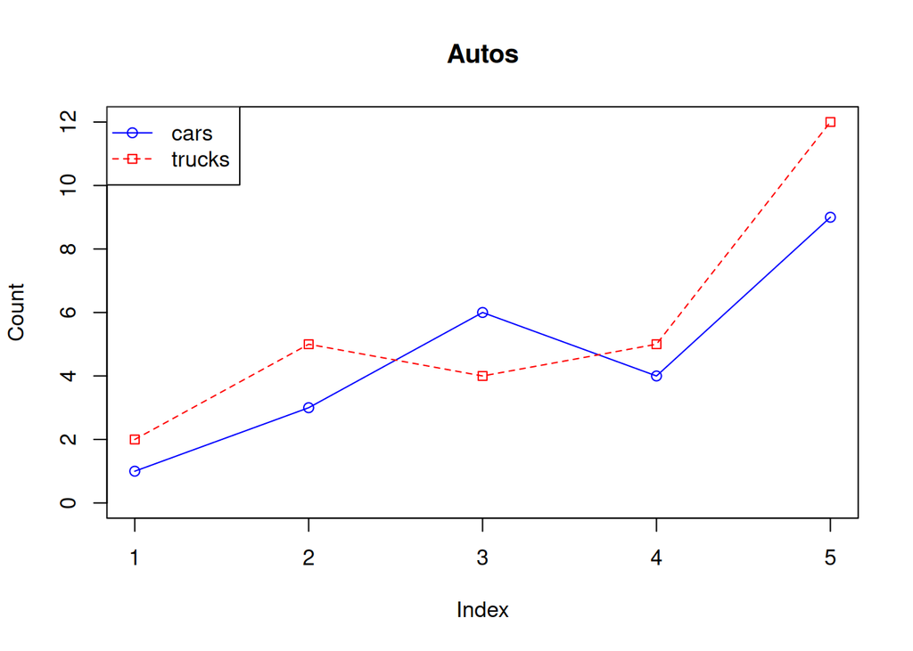

```r
# Data vectors
cars <- c(1, 3, 6, 4, 9)
trucks <- c(2, 5, 4, 5, 12)

# Create a plot for 'cars' with points and lines
plot(cars, type = "o", col = "blue", ylim = c(0, 12),
     ylab = "Count", main = "Autos")

# Add a line for 'trucks' to the existing plot
lines(trucks, type = "o", pch = 22, lty = 2, col = "red")

# Add a legend
legend("topleft",
       legend = c("cars", "trucks"),
       col = c("blue", "red"),
       pch = 21:22,
       lty = 1:2)
```

### Bar Plots

Bar plots are used to display categorical data with rectangular bars.

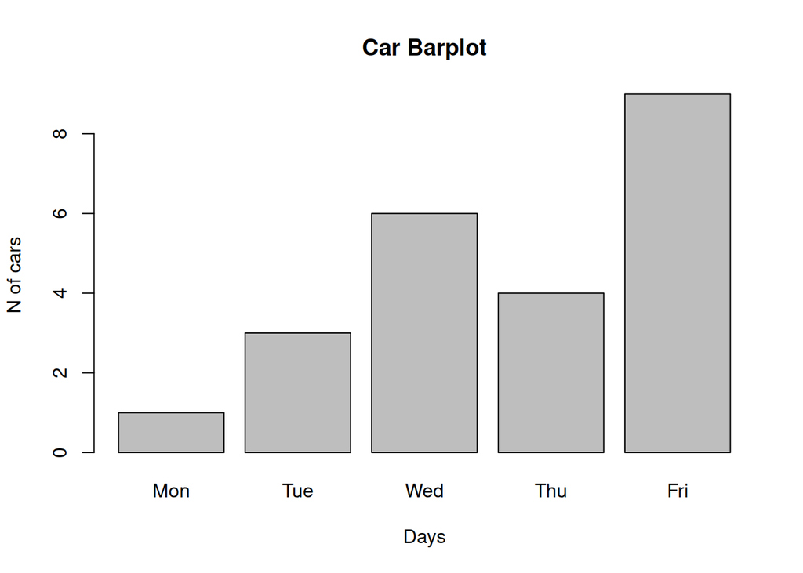

```r
# Data vector
days <- c("Mon", "Tue", "Wed", "Thu", "Fri")
cars <- c(1, 3, 6, 4, 9)

# Create the bar plot
barplot(cars,
        main = "Car Barplot",
        xlab = "Days",
        ylab = "N of cars",
        col = "grey",
        names.arg = days)
```

### Pie Charts

Pie charts represent proportions in a circle.

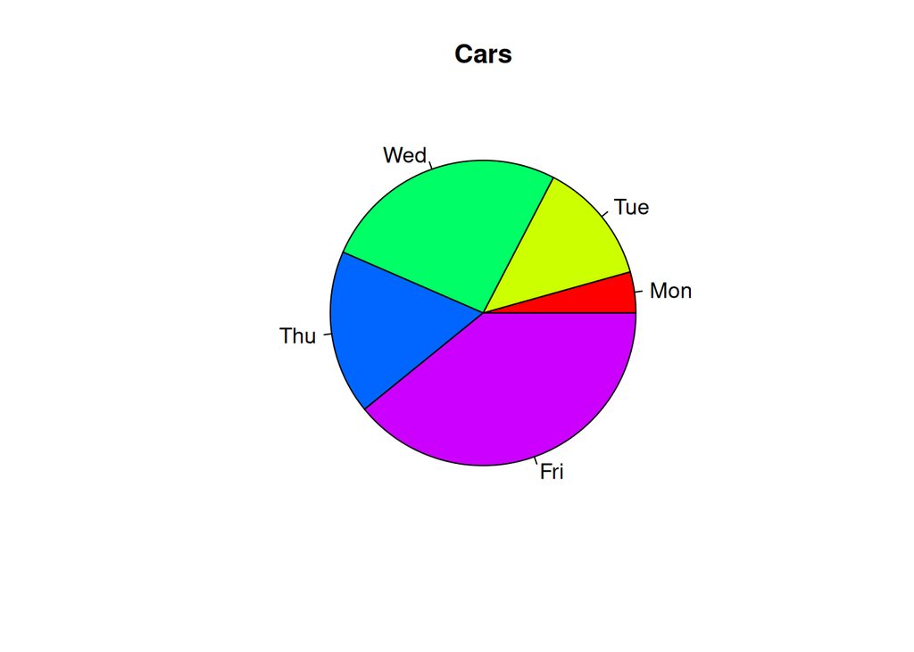

```r
# Data vector
cars <- c(1, 3, 6, 4, 9)
days <- c("Mon", "Tue", "Wed", "Thu", "Fri")

# Create the pie chart with colors and labels
pie(cars,
    main = "Cars",
    col = rainbow(length(cars)),
    labels = days)
```

### Histograms

Histograms visualize the distribution of a single continuous variable by dividing the data into bins and counting the frequency of observations in each bin.

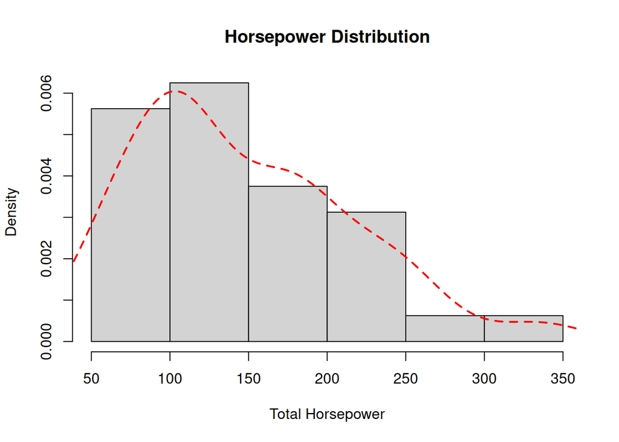

```r
# Use the built-in 'mtcars' dataset
# Look at the distribution of horsepower (hp)
hist(mtcars$hp,
     main = "Horsepower Distribution",
     xlab = "Total Horsepower",
     prob = TRUE) # Show density instead of frequency

# Add a density line
lines(density(mtcars$hp), col = "red", lwd = 2, lty = 2)
```

### Boxplots

Boxplots (or box-and-whisker plots) display the distribution of data based on a five-number summary (minimum, first quartile, median, third quartile, and maximum). They are excellent for comparing distributions across different groups.

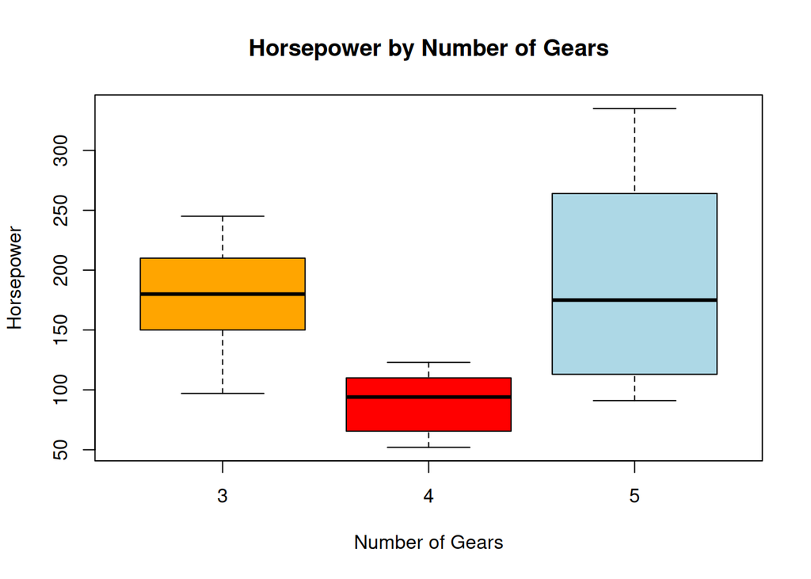

```r
# Use the built-in 'mtcars' dataset
# Compare horsepower (hp) by the number of gears (gear)
boxplot(hp ~ gear,
        data = mtcars,
        main = "Horsepower by Number of Gears",
        xlab = "Number of Gears",
        ylab = "Horsepower",
        col = c("orange", "red", "lightblue"))
```

## Descriptive Statistics

Descriptive statistics summarize the central tendency, dispersion, and shape of a dataset’s distribution.

```r
# Use the 'faithful' dataset
eruption_duration <- faithful$eruptions

# Central Tendency
mean(eruption_duration)
```

```
[1] 3.487783
```

```r
median(eruption_duration)
```

```
[1] 4
```

```r
# Position
quantile(eruption_duration) # Quartiles
```

```
     0%     25%     50%     75%    100%
1.60000 2.16275 4.00000 4.45425 5.10000
```

```r
quantile(eruption_duration, probs = c(0.1, 0.9)) # 10th and 90th percentiles
```

```
   10%    90%
1.8517 4.7000
```

```r
# Dispersion
range_val <- max(eruption_duration) - min(eruption_duration)
range_val
```

```
[1] 3.5
```

```r
IQR(eruption_duration) # Interquartile Range
```

```
[1] 2.2915
```

```r
var(eruption_duration) # Variance
```

```
[1] 1.302728
```

```r
sd(eruption_duration)  # Standard Deviation
```

```
[1] 1.141371
```

```r
# Covariance
waiting_time <- faithful$waiting
cov(eruption_duration, waiting_time)
```

```
[1] 13.97781
```